# 01_regresion_lineal

Francisco Paz

2/9/2020

El propósito de este r-markdown es prácticar la regresión lineal usando R (más adelante veremos como funciona lo mismo pero en Python).

Como vimos la clase pasada, existen distintas aproximaciones al problema, uno de ellos es el uso de mínimos cuadrados; en este caso veremos la implementación usando **Gradiente Descendente** y lo compararemos con la funcion *lm* que viene en la paquetería básica de R.

```r
z_0 <- 5
eta <- 0.4
descenso <- function(n, z_0, eta, h_deriv){
  z <- matrix(0,n, length(z_0))
  z[1, ] <- z_0
  for(i in 1:(n-1)){
    z[i+1, ] <- z[i, ] - eta * h_deriv(z[i, ])
  }
  z
}
```

```r
grad_calc <- function(x_ent, y_ent){
  salida_grad <- function(beta){
    f_beta <- as.matrix(cbind(1, x_ent)) %*% beta
    e <- y_ent - f_beta
    grad_out <- -as.numeric(t(cbind(1, x_ent)) %*% e)
    names(grad_out) <- c('Intercept', colnames(x_ent))
    grad_out
  }
  salida_grad
}
```

```r
rss_calc <- function(datos){
  # esta función recibe los datos (x,y) y devuelve
  # una función f(betas) que calcula rss
  y <- datos$lpsa
  x <- datos$lcavol
  fun_out <- function(beta){
    y_hat <- beta[1] + beta[2]*x
    e <- (y - y_hat)
    rss <- sum(e^2)
    0.5*rss
  }
  fun_out
}
```

```r
prostata <- read_csv('datos/prostate.csv') %>% select(lcavol, lpsa, train)
kable(head(prostata), digits = 4)
```

| lcavol | lpsa | train |
| --- | --- | --- |
| -0.5798 | -0.4308 | TRUE |
| -0.9943 | -0.1625 | TRUE |
| -0.5108 | -0.1625 | TRUE |
| -1.2040 | -0.1625 | TRUE |
| 0.7514 | 0.3716 | TRUE |
| -1.0498 | 0.7655 | TRUE |

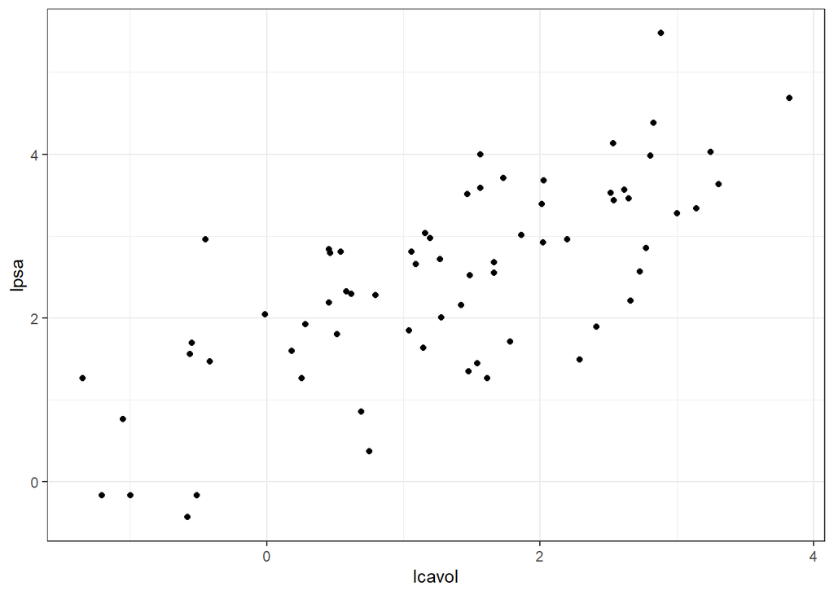

```r
prostata_entrena <- filter(prostata, train)
ggplot(prostata_entrena, aes(x = lcavol, y = lpsa)) + geom_point() + theme_bw()
```

```r
rss_prostata <- rss_calc(prostata_entrena)
beta <- c(0,1.5)
rss_prostata(beta)
```

```
## [1] 61.63861
```

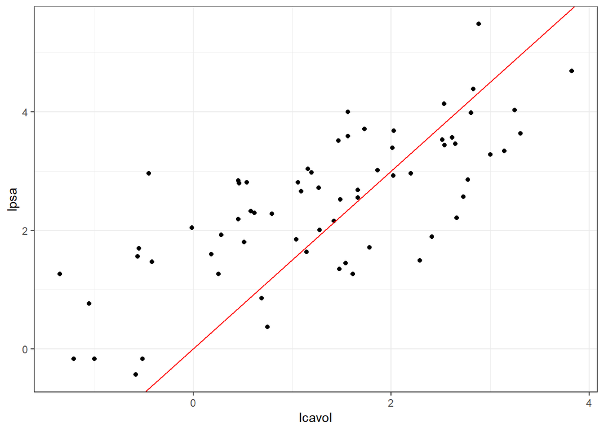

```r
ggplot(prostata_entrena, aes(x = lcavol, y = lpsa)) + geom_point() +
  geom_abline(slope = beta[2], intercept = beta[1], col ='red') + theme_bw()
```

```r
beta <- c(1,1)
rss_prostata(beta)
```

```
## [1] 27.11781
```

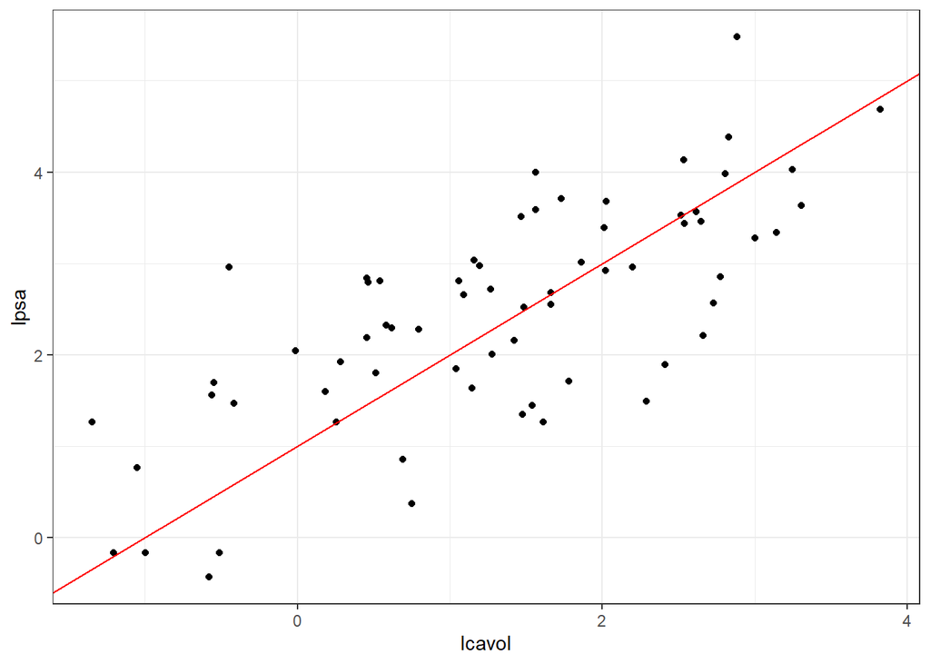

```r
ggplot(prostata_entrena, aes(x = lcavol, y = lpsa)) + geom_point() +
  geom_abline(slope = beta[2], intercept = beta[1], col ='red') + theme_bw()
```

```r
grad_prostata <- grad_calc(prostata_entrena[, 1, drop = FALSE], prostata_entrena$lpsa)
grad_prostata(c(0,1))
```

```
## Intercept    lcavol
## -76.30319 -70.93938
```

```r
grad_prostata(c(1,1))
```

```
## Intercept    lcavol
## -9.303187 17.064556
```

```r
iteraciones <- descenso(100, c(0,0), 0.005, grad_prostata)
iteraciones
```

```
##             [,1]      [,2]
##   [1,] 0.0000000 0.0000000
##   [2,] 0.8215356 1.4421892
##   [3,] 0.7332652 0.9545169
##   [4,] 0.8891507 1.0360252
##   [5,] 0.9569494 0.9603012
##   [6,] 1.0353555 0.9370937
##   [7,] 1.0977074 0.9046239
##   [8,] 1.1534587 0.8800287
##   [9,] 1.2013557 0.8576489
##  [10,] 1.2430547 0.8385314
##  [11,] 1.2791967 0.8218556
##  [12,] 1.3105688 0.8074114
##  [13,] 1.3377869 0.7948709
##  [14,] 1.3614051 0.7839915
```

[output cut: 86 more lines]

```r
iteraciones[100,1]
```

```
## [1] 1.516304
```

Finalmente comparamos con la función *lm*

```r
(modelo <- lm(prostata_entrena$lpsa ~ prostata_entrena$lcavol))
```

```
##
## Call:
## lm(formula = prostata_entrena$lpsa ~ prostata_entrena$lcavol)
##
## Coefficients:
##             (Intercept)  prostata_entrena$lcavol
##                  1.5163                   0.7126
```

```r
summary(modelo)
```

```
##
## Call:
## lm(formula = prostata_entrena$lpsa ~ prostata_entrena$lcavol)
##
## Residuals:
##     Min      1Q  Median      3Q     Max
## -1.6802 -0.4240  0.1684  0.5392  1.9070
##
## Coefficients:
##                         Estimate Std. Error t value Pr(>|t|)
## (Intercept)              1.51630    0.14772  10.264 3.12e-15 ***
## prostata_entrena$lcavol  0.71264    0.08199   8.692 1.73e-12 ***
## ---
## Signif. codes:  0 '***' 0.001 '**' 0.01 '*' 0.05 '.' 0.1 ' ' 1
##
## Residual standard error: 0.8277 on 65 degrees of freedom
## Multiple R-squared:  0.5375, Adjusted R-squared:  0.5304
## F-statistic: 75.55 on 1 and 65 DF,  p-value: 1.733e-12
```

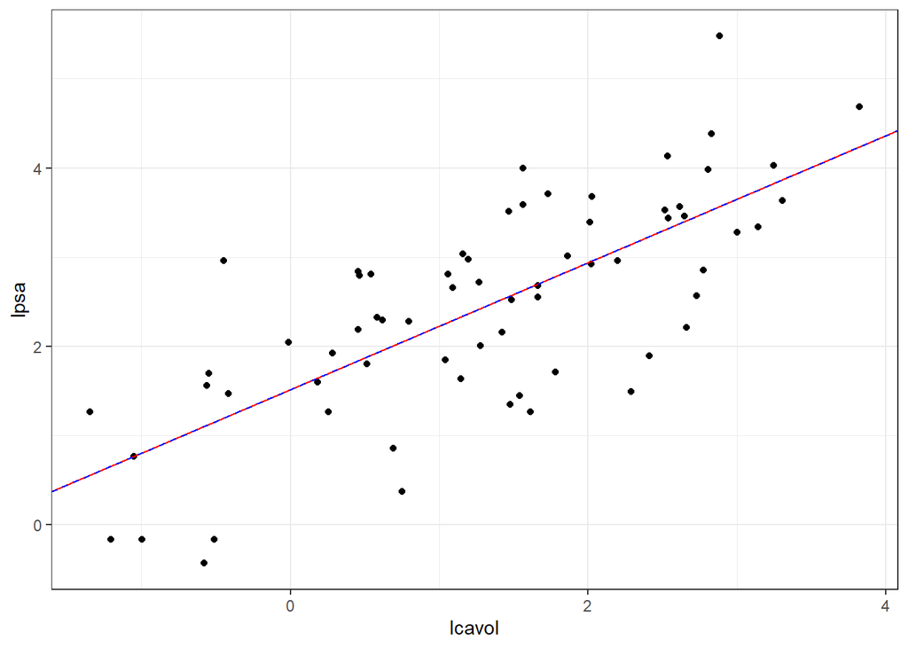

```r
ggplot(prostata_entrena, aes(x = lcavol, y = lpsa)) + geom_point() +
  geom_abline(slope = iteraciones[100,2] , intercept =iteraciones[100,1], col ='red') +
  geom_abline(slope = modelo$coefficients[2], intercept = modelo$coefficients[1]
              , col ='blue',linetype="dashed")+
  theme_bw()
```

Vimos un ejemplo de regresión lineal **simple** usando **gradiente en descenso** y con la función **lm** (del paquete básico de R). ¿Puedes pensar en algún problema causado por el uso de gradiente descendente?

- Es bastante recomendable normalizar las entradas, para evitar tener problemas al momento de movernos.

A continuación se presentan algunos ejercicios para consolidar el uso de **lm** para regresión.

1. Utilizando la base de datos *cars* realiza los siguientes ejercicios.
- Un análisis exploratorio (al menos un scatter plot) de la base

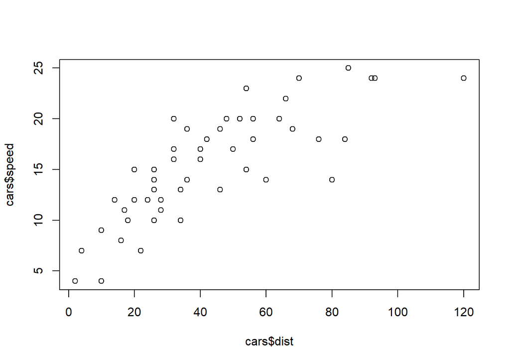

```r
plot(cars$dist,cars$speed)
```

- Realiza la regresión utilizando la función *lm* y la función de gradiente que construimos.

```r
cars <- cars
kable(head(cars))
```

| speed | dist |
| --- | --- |
| 4 | 2 |
| 4 | 10 |
| 7 | 4 |
| 7 | 22 |
| 8 | 16 |
| 9 | 10 |

```r
modelo <-  lm(cars$dist ~ cars$speed)
modelo
```

```
##
## Call:
## lm(formula = cars$dist ~ cars$speed)
##
## Coefficients:
## (Intercept)   cars$speed
##     -17.579        3.932
```

```r
summary(modelo)
```

```
##
## Call:
## lm(formula = cars$dist ~ cars$speed)
##
## Residuals:
##     Min      1Q  Median      3Q     Max
## -29.069  -9.525  -2.272   9.215  43.201
##
## Coefficients:
##             Estimate Std. Error t value Pr(>|t|)
## (Intercept) -17.5791     6.7584  -2.601   0.0123 *
## cars$speed    3.9324     0.4155   9.464 1.49e-12 ***
## ---
## Signif. codes:  0 '***' 0.001 '**' 0.01 '*' 0.05 '.' 0.1 ' ' 1
##
## Residual standard error: 15.38 on 48 degrees of freedom
## Multiple R-squared:  0.6511, Adjusted R-squared:  0.6438
## F-statistic: 89.57 on 1 and 48 DF,  p-value: 1.49e-12
```

```r
grad_cars<- grad_calc(cars$speed,cars$dist)
iteraciones <- descenso(100,c(0,0),0.005,grad_cars)
iteraciones
```

```
##                  [,1]           [,2]
##   [1,]   0.000000e+00   0.000000e+00
##   [2,]   1.074500e+01   1.924100e+02
##   [3,]  -7.219748e+02  -1.238255e+04
##   [4,]   4.714206e+04   8.095710e+05
##   [5,]  -3.081481e+06  -5.291676e+07
##   [6,]   2.014184e+08   3.458862e+09
##   [7,]  -1.316555e+10  -2.260857e+11
##   [8,]   8.605558e+11   1.477791e+13
##   [9,]  -5.624954e+13  -9.659463e+14
##  [10,]   3.676706e+15   6.313830e+16
##  [11,]  -2.403249e+17  -4.126984e+18
##  [12,]   1.570865e+19   2.697570e+20
##  [13,]  -1.026783e+21  -1.763245e+22
##  [14,]   6.711484e+22   1.152531e+24
```

[output cut: 86 more lines]

Como vimo en clase, la escala de las variables es muy importante para la solución del problema. Notemos que se reescalan las variables y el algoritmos ya converge! (a diferencia del problema que vimos en clase).

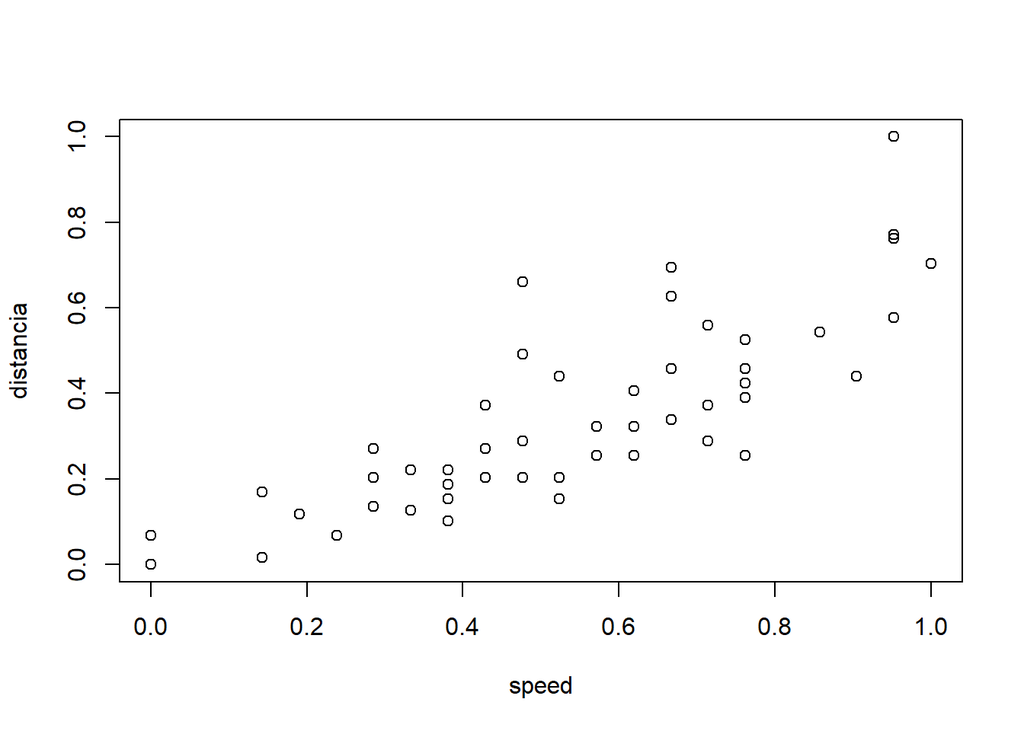

```r
speed <- rescale(cars$speed )
distancia <- rescale(cars$dist)
plot(speed, distancia)
```

```r
lm(distancia ~ speed)
```

```
##
## Call:
## lm(formula = distancia ~ speed)
##
## Coefficients:
## (Intercept)        speed
##    -0.03262      0.69984
```

Puedes tratar de cambiar el paso de aprendizaje $\eta = 0.005$ y ver que ocurre.

```r
grad_cars<- grad_calc(speed,distancia)
iteraciones <- descenso(100000,c(0,0),0.005,grad_cars)
tail(iteraciones)
```

```
##                  [,1]      [,2]
##  [99995,] -0.03262254 0.6998355
##  [99996,] -0.03262254 0.6998355
##  [99997,] -0.03262254 0.6998355
##  [99998,] -0.03262254 0.6998355
##  [99999,] -0.03262254 0.6998355
## [100000,] -0.03262254 0.6998355
```

2. La base de datos *Boston* (también incluida en r básico ) contiene información acerca de casa en Boston (adivinaron). La idea sería construir una regresión lineal simple y una múltiple para calcular la variable **medv**.
- Selecciona una variable que creeas esta altamente relacionada con el precio (si necesitas saber el significado de cada variable, puedes usar)

```r
?Boston
```

- Toma al menos 3 variables y realiza una regresión lineal múltiple.

Aquí cargamos la vase y mostramos las primeras observaciones de la misma.

```r
boston <- Boston
kable(head(boston))
```

| crim | zn | indus | chas | nox | rm | age | dis | rad | tax | ptratio | black | lstat | medv |
| --- | --- | --- | --- | --- | --- | --- | --- | --- | --- | --- | --- | --- | --- |
| 0.00632 | 18 | 2.31 | 0 | 0.538 | 6.575 | 65.2 | 4.0900 | 1 | 296 | 15.3 | 396.90 | 4.98 | 24.0 |
| 0.02731 | 0 | 7.07 | 0 | 0.469 | 6.421 | 78.9 | 4.9671 | 2 | 242 | 17.8 | 396.90 | 9.14 | 21.6 |
| 0.02729 | 0 | 7.07 | 0 | 0.469 | 7.185 | 61.1 | 4.9671 | 2 | 242 | 17.8 | 392.83 | 4.03 | 34.7 |
| 0.03237 | 0 | 2.18 | 0 | 0.458 | 6.998 | 45.8 | 6.0622 | 3 | 222 | 18.7 | 394.63 | 2.94 | 33.4 |
| 0.06905 | 0 | 2.18 | 0 | 0.458 | 7.147 | 54.2 | 6.0622 | 3 | 222 | 18.7 | 396.90 | 5.33 | 36.2 |
| 0.02985 | 0 | 2.18 | 0 | 0.458 | 6.430 | 58.7 | 6.0622 | 3 | 222 | 18.7 | 394.12 | 5.21 | 28.7 |

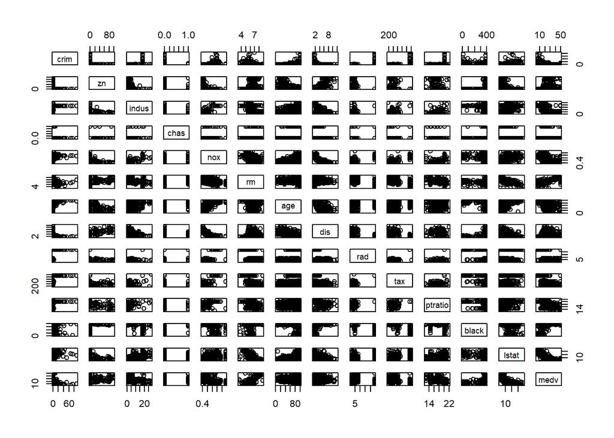

```r
pairs(boston)
```

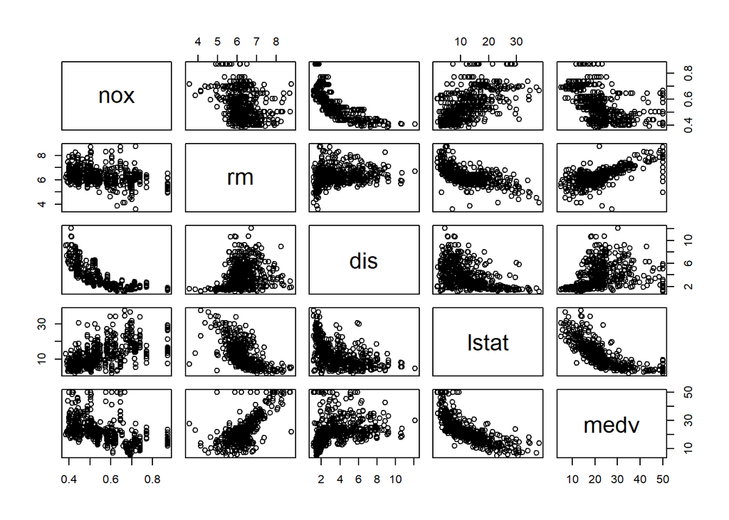

```r
pairs(boston[,c(5,6,8,13,14)])
```

```r
(modelo1 <- lm(medv ~ rm , data=boston))
```

```
##
## Call:
## lm(formula = medv ~ rm, data = boston)
##
## Coefficients:
## (Intercept)           rm
##     -34.671        9.102
```

```r
summary(modelo1)
```

```
##
## Call:
## lm(formula = medv ~ rm, data = boston)
##
## Residuals:
##     Min      1Q  Median      3Q     Max
## -23.346  -2.547   0.090   2.986  39.433
##
## Coefficients:
##             Estimate Std. Error t value Pr(>|t|)
## (Intercept)  -34.671      2.650  -13.08   <2e-16 ***
## rm             9.102      0.419   21.72   <2e-16 ***
## ---
## Signif. codes:  0 '***' 0.001 '**' 0.01 '*' 0.05 '.' 0.1 ' ' 1
##
## Residual standard error: 6.616 on 504 degrees of freedom
## Multiple R-squared:  0.4835, Adjusted R-squared:  0.4825
## F-statistic: 471.8 on 1 and 504 DF,  p-value: < 2.2e-16
```

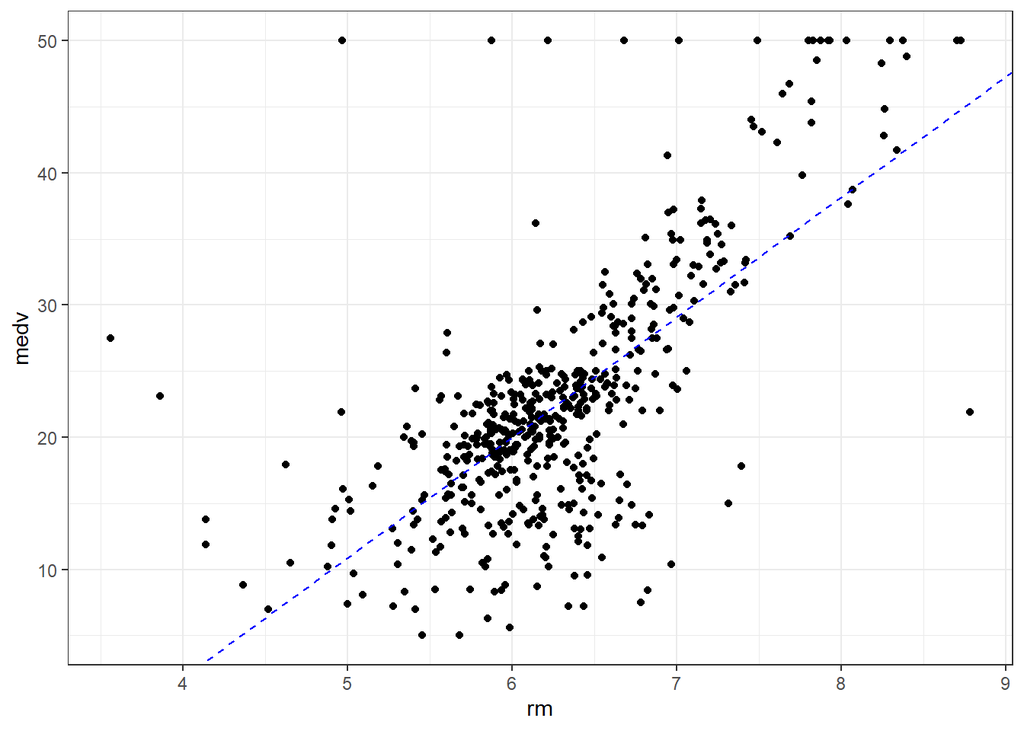

```r
ggplot(boston, aes(x = rm, y = medv)) + geom_point() +
  geom_abline(slope = modelo1$coefficients[2], intercept = modelo1$coefficients[1]
              , col ='blue',linetype="dashed")+
  theme_bw()
```

Para el caso de regrsión multiple solo agregaremos las variables que nos interesan al comando del modelo.

```r
(modelo <- lm(medv ~ nox + rm + dis + lstat , data=boston))
```

```
##
## Call:
## lm(formula = medv ~ nox + rm + dis + lstat, data = boston)
##
## Coefficients:
## (Intercept)          nox           rm          dis        lstat
##     12.0360     -14.5379       4.8634      -0.9670      -0.6587
```

```r
summary(modelo)
```

```
##
## Call:
## lm(formula = medv ~ nox + rm + dis + lstat, data = boston)
##
## Residuals:
##     Min      1Q  Median      3Q     Max
## -17.072  -3.228  -0.907   1.968  26.402
##
## Coefficients:
##              Estimate Std. Error t value Pr(>|t|)
## (Intercept)  12.03600    3.99033   3.016  0.00269 **
## nox         -14.53791    3.49991  -4.154 3.84e-05 ***
## rm            4.86340    0.43754  11.115  < 2e-16 ***
## dis          -0.96699    0.18018  -5.367 1.23e-07 ***
## lstat        -0.65865    0.05099 -12.917  < 2e-16 ***
## ---
## Signif. codes:  0 '***' 0.001 '**' 0.01 '*' 0.05 '.' 0.1 ' ' 1
##
## Residual standard error: 5.396 on 501 degrees of freedom
## Multiple R-squared:  0.6585, Adjusted R-squared:  0.6558
## F-statistic: 241.6 on 4 and 501 DF,  p-value: < 2.2e-16
```

¿Se te ocurre alguna forma de ver el ajuste como en el caso lineal?

La idea de la siguiente gráfica es simple, queremos que los valores **ajustados** vs los valores **reales** queden dentro de la linea identidad.

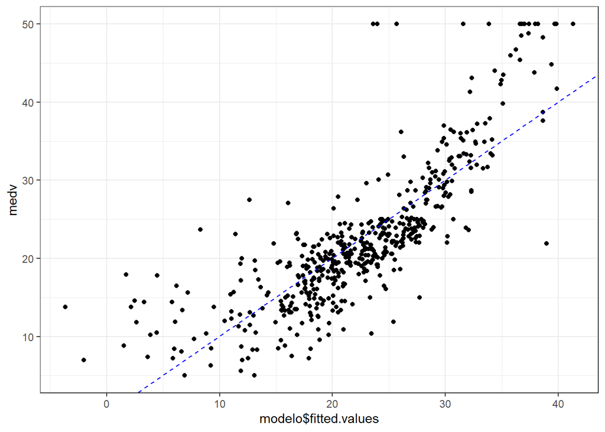

```r
g1 <- ggplot(boston, aes(x = modelo$fitted.values, y = medv)) + geom_point() +
  geom_abline(slope = 1, intercept = 0
              , col ='blue',linetype="dashed")+
  theme_bw()

g1
```

Por ejemplo, para la regresión simple se vería así la gráfica:

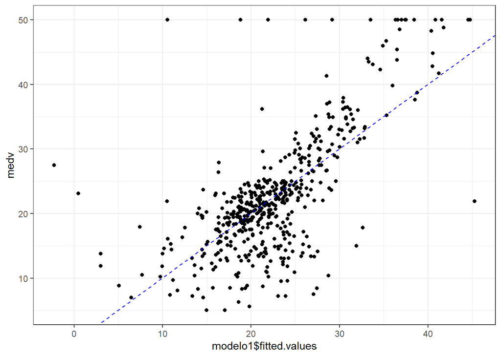

```r
g0 <- ggplot(boston, aes(x = modelo1$fitted.values, y = medv)) + geom_point() +
  geom_abline(slope = 1, intercept = 0
              , col ='blue',linetype="dashed")+
  theme_bw()

g0
```

¿cómo harías para agregar todas las variables al análisis?

```r
(modelo <- lm(medv ~ ., data = boston))
```

```
##
## Call:
## lm(formula = medv ~ ., data = boston)
##
## Coefficients:
## (Intercept)         crim           zn        indus         chas
##   3.646e+01   -1.080e-01    4.642e-02    2.056e-02    2.687e+00
##         nox           rm          age          dis          rad
##  -1.777e+01    3.810e+00    6.922e-04   -1.476e+00    3.060e-01
##         tax      ptratio        black        lstat
##  -1.233e-02   -9.527e-01    9.312e-03   -5.248e-01
```

```r
summary(modelo)
```

```
##
## Call:
## lm(formula = medv ~ ., data = boston)
##
## Residuals:
##     Min      1Q  Median      3Q     Max
## -15.595  -2.730  -0.518   1.777  26.199
##
## Coefficients:
##               Estimate Std. Error t value Pr(>|t|)
## (Intercept)  3.646e+01  5.103e+00   7.144 3.28e-12 ***
## crim        -1.080e-01  3.286e-02  -3.287 0.001087 **
## zn           4.642e-02  1.373e-02   3.382 0.000778 ***
## indus        2.056e-02  6.150e-02   0.334 0.738288
## chas         2.687e+00  8.616e-01   3.118 0.001925 **
## nox         -1.777e+01  3.820e+00  -4.651 4.25e-06 ***
## rm           3.810e+00  4.179e-01   9.116  < 2e-16 ***
## age          6.922e-04  1.321e-02   0.052 0.958229
## dis         -1.476e+00  1.995e-01  -7.398 6.01e-13 ***
## rad          3.060e-01  6.635e-02   4.613 5.07e-06 ***
## tax         -1.233e-02  3.760e-03  -3.280 0.001112 **
## ptratio     -9.527e-01  1.308e-01  -7.283 1.31e-12 ***
## black        9.312e-03  2.686e-03   3.467 0.000573 ***
## lstat       -5.248e-01  5.072e-02 -10.347  < 2e-16 ***
## ---
## Signif. codes:  0 '***' 0.001 '**' 0.01 '*' 0.05 '.' 0.1 ' ' 1
##
## Residual standard error: 4.745 on 492 degrees of freedom
## Multiple R-squared:  0.7406, Adjusted R-squared:  0.7338
## F-statistic: 108.1 on 13 and 492 DF,  p-value: < 2.2e-16
```

¿Notas algun error?

```r
boston$chas <- as.factor(boston$chas)
```

```r
(modelo <- lm(medv ~ ., data = boston))
```

```
##
## Call:
## lm(formula = medv ~ ., data = boston)
##
## Coefficients:
## (Intercept)         crim           zn        indus        chas1
##   3.646e+01   -1.080e-01    4.642e-02    2.056e-02    2.687e+00
##         nox           rm          age          dis          rad
##  -1.777e+01    3.810e+00    6.922e-04   -1.476e+00    3.060e-01
##         tax      ptratio        black        lstat
##  -1.233e-02   -9.527e-01    9.312e-03   -5.248e-01
```

```r
summary(modelo)
```

```
##
## Call:
## lm(formula = medv ~ ., data = boston)
##
## Residuals:
##     Min      1Q  Median      3Q     Max
## -15.595  -2.730  -0.518   1.777  26.199
##
## Coefficients:
##               Estimate Std. Error t value Pr(>|t|)
## (Intercept)  3.646e+01  5.103e+00   7.144 3.28e-12 ***
## crim        -1.080e-01  3.286e-02  -3.287 0.001087 **
## zn           4.642e-02  1.373e-02   3.382 0.000778 ***
## indus        2.056e-02  6.150e-02   0.334 0.738288
## chas1        2.687e+00  8.616e-01   3.118 0.001925 **
## nox         -1.777e+01  3.820e+00  -4.651 4.25e-06 ***
## rm           3.810e+00  4.179e-01   9.116  < 2e-16 ***
## age          6.922e-04  1.321e-02   0.052 0.958229
## dis         -1.476e+00  1.995e-01  -7.398 6.01e-13 ***
## rad          3.060e-01  6.635e-02   4.613 5.07e-06 ***
## tax         -1.233e-02  3.760e-03  -3.280 0.001112 **
## ptratio     -9.527e-01  1.308e-01  -7.283 1.31e-12 ***
## black        9.312e-03  2.686e-03   3.467 0.000573 ***
## lstat       -5.248e-01  5.072e-02 -10.347  < 2e-16 ***
## ---
## Signif. codes:  0 '***' 0.001 '**' 0.01 '*' 0.05 '.' 0.1 ' ' 1
##
## Residual standard error: 4.745 on 492 degrees of freedom
## Multiple R-squared:  0.7406, Adjusted R-squared:  0.7338
## F-statistic: 108.1 on 13 and 492 DF,  p-value: < 2.2e-16
```

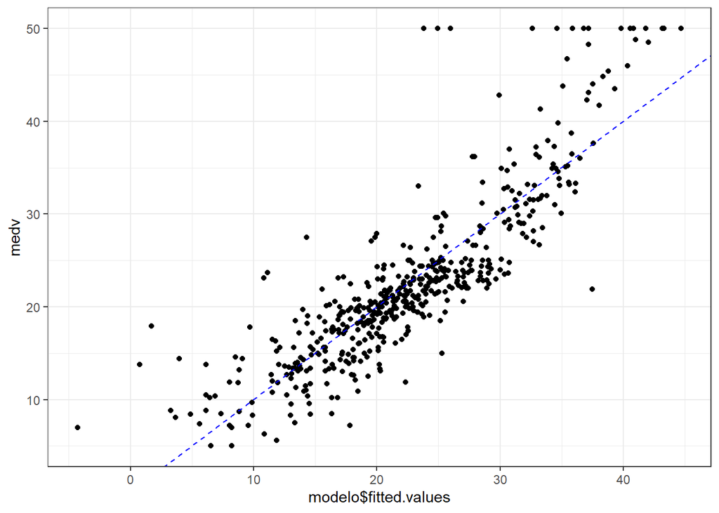

```r
g2 <- ggplot(boston, aes(x = modelo$fitted.values, y = medv)) + geom_point() +
  geom_abline(slope = 1, intercept = 0
              , col ='blue',linetype="dashed")+
  theme_bw()

g2
```

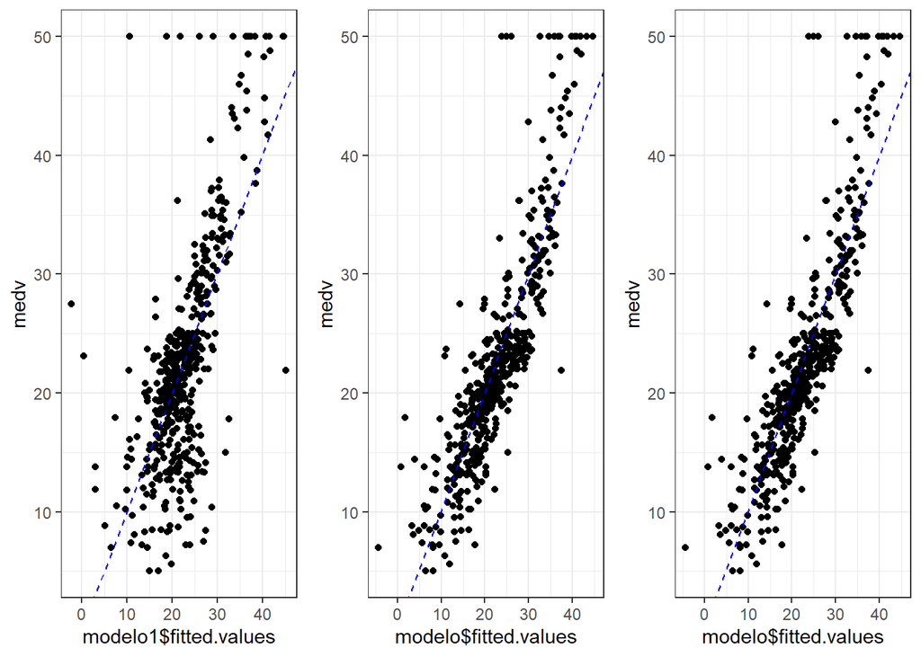

```r
#library(gridExtra)
grid.arrange(g0,g1,g2,nrow=1)
```